# TFM Regles d’associacions

9 de febrer de 2021

## Regles d’associacions

En aquest apartat se cercarà les rutes més habituals dels individus a dins la ciutat de Palma a través de les regles d’associació. Es tendran en compte les franges horàries per realitzar l’estudi, no és el mateix un dilluns dematí que un diumenge horabaixa. Però en aquest estudi no es tendran en compte, ja que sols es recollirà una mostra.

Una possible aplicació és l’optimització de les rutes del transport públic, reordenadores o augmentant o baixant la freqüència.

Es realitzarà dues aproximacions: - Associacions dels noms dels APs - Associacions de les àrees dels APs

Perquè funcioni aquest algoritme, s’han de crear dos csv amb la codificació necessària que requereix la llibreria necessària que és la de 1 hot encoded.

#Llibreries necessàries

```r
library(arules)
library(dplyr)
```

```r
library(arulesViz)
```

## Carregar la base de dades

Es carrega les dades d’un dia i es recull una petita mostra.

```r
dades = read.csv("~/Escritorio/TFM/observacionsEstiu20190724mod.csv", header = TRUE, sep = ';')
dades.train = head(dades, round(length(dades$idreg)*0.05))
str(dades.train)
```

```
## 'data.frame':    191663 obs. of  10 variables:
##  $ idreg    : Factor w/ 3833267 levels "000d4f7a-20bd-11ea-9849-080027f7d687",..: 631014 631015 631016 631017 631018 631019 631020 631021 631022 631023 ...
##  $ clientmac: Factor w/ 224375 levels "00:00:00:44:78:9c",..: 130496 48874 222287 1784 158705 163081 72 163081 163081 73 ...
##  $ lat      : num  39.6 39.6 39.6 39.6 39.6 ...
##  $ lng      : num  2.63 2.64 2.64 2.64 2.64 ...
##  $ seendate : logi  NA NA NA NA NA NA ...
##  $ seentime : int  1563988648 1564008125 1563998527 1563979981 1563971171 1563943361 1563930230 1563945813 1563946242 1564010537 ...
##  $ apmac    : Factor w/ 173 levels "00:18:0a:03:04:bc",..: 25 26 26 26 26 27 27 27 27 27 ...
##  $ model    : logi  NA NA NA NA NA NA ...
##  $ ssid     : logi  NA NA NA NA NA NA ...
##  $ lloc     : logi  NA NA NA NA NA NA ...
```

```r
head(dades.train)
```

```
##                                  idreg         clientmac      lat      lng
## 1 2e14a25a-20b9-11ea-9849-080027f7d687 a8:0c:63:b2:3f:6c 39.56706 2.630230
## 2 2e14a25b-20b9-11ea-9849-080027f7d687 38:ca:da:97:f2:00 39.56675 2.644041
## 3 2e14a25c-20b9-11ea-9849-080027f7d687 f8:95:ea:07:3c:e4 39.56675 2.644040
## 4 2e14a25d-20b9-11ea-9849-080027f7d687 00:1a:dd:54:4c:24 39.56689 2.643955
## 5 2e14a25e-20b9-11ea-9849-080027f7d687 c0:a6:00:68:16:ff 39.56675 2.644041
## 6 2e14a25f-20b9-11ea-9849-080027f7d687 c8:3a:35:dc:92:a3 39.56665 2.643939
##   seendate   seentime             apmac model ssid lloc
## 1       NA 1563988648 00:18:0a:04:74:d0    NA   NA   NA
## 2       NA 1564008125 00:18:0a:04:78:72    NA   NA   NA
## 3       NA 1563998527 00:18:0a:04:78:72    NA   NA   NA
## 4       NA 1563979981 00:18:0a:04:78:72    NA   NA   NA
## 5       NA 1563971171 00:18:0a:04:78:72    NA   NA   NA
## 6       NA 1563943361 00:18:0a:04:a1:ca    NA   NA   NA
```

## Combinar dues bases de dades

Per no veure relacions entre macs APs, cosa que dificulta el seu enteniment, llavors es combinarà amb la taula ampliada de la distribució aps ampliat que contenen el nom dels APs i el nom de la zona on estan.

```r
nomsAP = read.csv("~/Escritorio/TFM/distribucioapsampliat.csv", header = TRUE, sep = ',')
str(nomsAP)
```

```
## 'data.frame':    198 obs. of  6 variables:
##  $ mac      : Factor w/ 198 levels "00:18:0a:03:04:bc",..: 27 28 15 120 135 131 88 114 92 80 ...
##  $ name     : Factor w/ 196 levels "Ajuntament de Palma 1",..: 159 158 113 114 157 156 51 50 52 116 ...
##  $ lat      : num  39.6 39.6 39.6 39.6 39.6 ...
##  $ lng      : num  2.64 2.64 2.64 2.64 2.64 ...
##  $ zona     : Factor w/ 53 levels "SmartWiFiPalma Zona 0",..: 1 1 1 1 1 1 2 2 2 2 ...
##  $ zona_name: Factor w/ 54 levels "Arenal","Av. Jaume III",..: 18 18 18 18 18 18 23 23 23 23 ...
```

```r
head(nomsAP)
```

```
##                 mac                                    name      lat      lng
## 1 00:18:0a:04:78:72             Mar de Nudos - Gat. Terraza 39.56675 2.644041
## 2 00:18:0a:04:a1:ca        Mar de Nudos - Gat. Mar de Nudos 39.56665 2.643939
## 3 00:18:0a:03:12:1a                Gat. Moll Vell - Amarres 39.56608 2.643238
## 4 88:15:44:2c:34:60 Gat. Moll Vell - Restaurante Port Blanc 39.56623 2.643587
## 5 88:15:44:59:3e:d0          Gat. Varadero Parada Autobuses 39.56510 2.643442
## 6 88:15:44:59:07:80                           Gat. Varadero 39.56377 2.641878
##                    zona zona_name
## 1 SmartWiFiPalma Zona 0 Moll Vell
## 2 SmartWiFiPalma Zona 0 Moll Vell
## 3 SmartWiFiPalma Zona 0 Moll Vell
## 4 SmartWiFiPalma Zona 0 Moll Vell
## 5 SmartWiFiPalma Zona 0 Moll Vell
## 6 SmartWiFiPalma Zona 0 Moll Vell
```

Aquesta base de dades està actualizada, abans faltaben dades, la qual cosa milloraran els resultats

```r
combine = merge( dades.train, nomsAP, by.x = "apmac", by.y = "mac") #Es combinen les taules
```

## Aplicar l’algoritme primera part

En aquest algoritme solament es fa ús dels noms dels APs.

```r
mydata = data.frame(combine$clientmac, combine$name)
head(mydata)
```

```
##   combine.clientmac                   combine.name
## 1 ec:3d:fd:80:d1:0d Gat. Paseo Maritimo - Europcar
## 2 d4:e6:b7:95:6f:e9 Gat. Paseo Maritimo - Europcar
## 3 f4:71:90:61:89:af Gat. Paseo Maritimo - Europcar
## 4 04:d6:aa:fd:1c:74 Gat. Paseo Maritimo - Europcar
## 5 88:83:22:ac:63:de Gat. Paseo Maritimo - Europcar
## 6 00:15:5d:1f:17:cf Gat. Paseo Maritimo - Europcar
```

```r
write.csv(mydata,"datostratados.csv", row.names = FALSE)
```

Es crea l’objecte necessari per obtenir els itemsets freqüents.

```r
transactions.obj <- read.transactions(file = "~/Escritorio/TFM/datostratados.csv", format = "single",
                                      sep = ",",
                                      header = TRUE,
                                      cols = c("combine.clientmac","combine.name"),
                                      rm.duplicates = FALSE,
                                      quote = "", skip = 0,
                                      encoding = "unknown")
```

```r
transactions.obj
```

```
## transactions in sparse format with
##  38939 transactions (rows) and
##  89 items (columns)
```

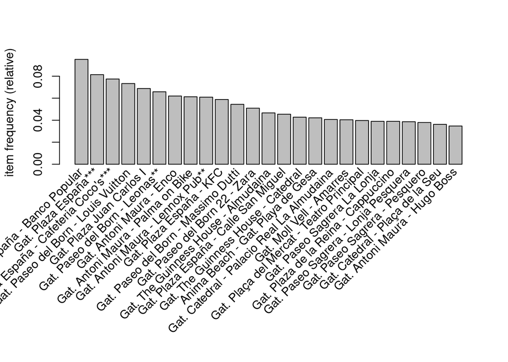

```r
itemFrequencyPlot(transactions.obj,topN = 25)
```

S’observa que la tendència per connectar-se a la xarxa està en els APs de la Plaça d’Espanya.

```r
Items1 <- apriori(transactions.obj, parameter = list(supp = 0.01, conf = 0.01, minlen=2))
```

```
## Apriori
##
## Parameter specification:
##  confidence minval smax arem  aval originalSupport maxtime support minlen
##        0.01    0.1    1 none FALSE            TRUE       5    0.01      2
##  maxlen target   ext
##      10  rules FALSE
##
## Algorithmic control:
##  filter tree heap memopt load sort verbose
##     0.1 TRUE TRUE  FALSE TRUE    2    TRUE
##
## Absolute minimum support count: 389
##
## set item appearances ...[0 item(s)] done [0.00s].
## set transactions ...[89 item(s), 38939 transaction(s)] done [0.01s].
## sorting and recoding items ... [51 item(s)] done [0.00s].
## creating transaction tree ... done [0.01s].
## checking subsets of size 1 2 3 done [0.00s].
## writing ... [70 rule(s)] done [0.00s].
## creating S4 object  ... done [0.00s].
```

```r
inspect(head(Items1))
```

```
##     lhs                                          rhs                                          support confidence     lift count
## [1] {Gat. Plaza Mayor - Lizarran}             => {Gat. Plaza Mayor - Cafetería Paris***}   0.01037520  0.3420830 9.985284   404
## [2] {Gat. Plaza Mayor - Cafetería Paris***}   => {Gat. Plaza Mayor - Lizarran}             0.01037520  0.3028486 9.985284   404
## [3] {Gat. Plaza España - Calle San Miguel}    => {Gat. Plaza España - Cafeteria Coco's***} 0.01132541  0.2491525 3.217828   441
## [4] {Gat. Plaza España - Cafeteria Coco's***} => {Gat. Plaza España - Calle San Miguel}    0.01132541  0.1462687 3.217828   441
## [5] {Gat. Plaza España - Calle San Miguel}    => {Gat. Plaza España - Banco Popular}       0.01006703  0.2214689 2.324469   392
## [6] {Gat. Plaza España - Banco Popular}       => {Gat. Plaza España - Calle San Miguel}    0.01006703  0.1056604 2.324469   392
```

```r
Items_conf <- sort (Items1, by="confidence", decreasing=TRUE) # 'high-confidence' rules.
inspect(head(Items_conf)) # show the support, lift and confidence for all rules
```

```
##     lhs                                      rhs                                            support confidence     lift count
## [1] {Gat. Paseo del Born - Massimo Dutti} => {Gat. Paseo del Born - Louis Vuitton}       0.01949203  0.3581878 4.885280   759
## [2] {Gat. Paseo del Born 22 - Zara}       => {Gat. Paseo del Born - Louis Vuitton}       0.01759162  0.3454362 4.711363   685
## [3] {Gat. Plaza Mayor - Lizarran}         => {Gat. Plaza Mayor - Cafetería Paris***}     0.01037520  0.3420830 9.985284   404
## [4] {Gat. Paseo del Born - Leonas**}      => {Gat. Paseo del Born - Louis Vuitton}       0.02175197  0.3304721 4.507269   847
## [5] {Gat. Plaza de la Reina - Cappuccino} => {Gat. Antoni Maura - Palma on Bike}         0.01245538  0.3194993 5.211975   485
## [6] {Gat. Catedral - Plaça de la Seu}     => {Gat. Catedral - Palacio Real La Almudaina} 0.01137677  0.3139617 7.722903   443
```

#Conclusió

#PLotejament de les dades Es disposa a dibuixar el graf amb les relacions més importants.

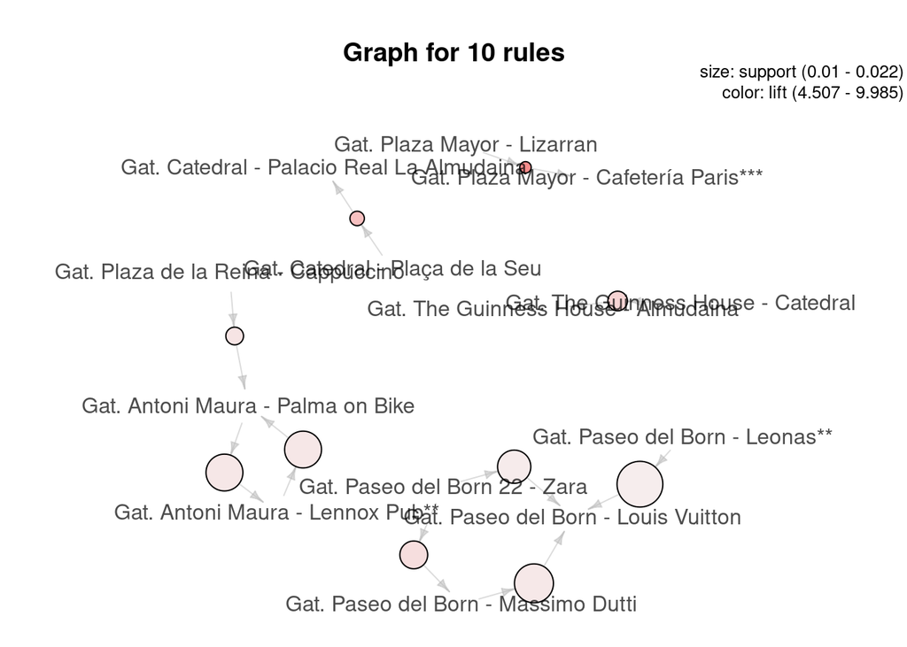

```r
subrules <- head(Items1, n = 10, by = "confidence")
plot(subrules, method = "graph")
```

#Conlcusió Un exemple que apareix aquest graf per la seva confiança és:
$$\{ Gat. \ The \ Guinness \ House - Catedral \} \rightarrow \{ Gat. \ The \ Guinness \ House - Almudaina \}$$
Aquests casos indiquen que les relacions obtingudes són d’APs que estan junts i donen aquests resultats. Per aquesta raó s’aplicarà un altra versió de l’algoritme, però en comptes d’utilitzar els noms s’utilitzaran les zones.

## Aplicar l’algoritme per zones

```r
dades.train = head(dades, round(length(dades$idreg)*0.10)) #Requereix de més entrades perque funcioni
combine = merge( dades.train, nomsAP, by.x = "apmac", by.y = "mac") #Es combinen les taules
mydata = data.frame(combine$clientmac, combine$zona_name)
head(mydata)
```

```
##   combine.clientmac combine.zona_name
## 1 5c:f9:38:b3:c3:32   Passeig maritim
## 2 68:72:51:56:2f:19   Passeig maritim
## 3 10:f1:f2:2a:00:ab   Passeig maritim
## 4 3c:77:e6:77:19:62   Passeig maritim
## 5 a0:c9:a0:ef:03:39   Passeig maritim
## 6 0c:cb:85:78:b3:64   Passeig maritim
```

```r
write.csv(mydata,"datostratados_zona_.csv", row.names = FALSE)
```

Es crea l’objecte necessari per obtenir els itemsets freqüents.

```r
transactions.obj <- read.transactions(file = "~/Escritorio/TFM/reglesassociacio/datostratados_zona.csv", format = "single",
                                      sep = ",",
                                      header = TRUE,
                                      cols = c("combine.clientmac","combine.zona_name"),
                                      rm.duplicates = FALSE,
                                      quote = "", skip = 0,
                                      encoding = "unknown")
```

```r
transactions.obj
```

```
## transactions in sparse format with
##  78098 transactions (rows) and
##  54 items (columns)
```

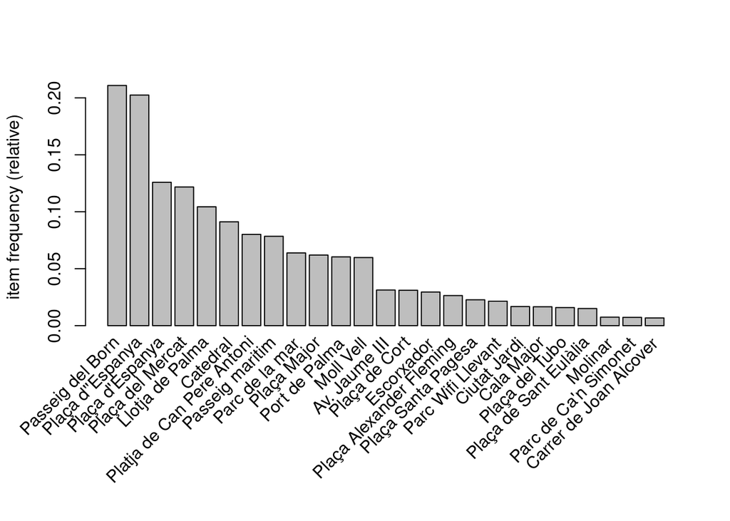

```r
itemFrequencyPlot(transactions.obj,topN = 25)
```

Ara és passarà a observar les regles més importants i dibuixar un graf amb les 10 més imporatnts.

```r
Items2 <- apriori(transactions.obj, parameter = list(supp = 0.0001, conf = 0.0001, minlen=2))
```

```
## Apriori
##
## Parameter specification:
##  confidence minval smax arem  aval originalSupport maxtime support minlen
##       1e-04    0.1    1 none FALSE            TRUE       5   1e-04      2
##  maxlen target   ext
##      10  rules FALSE
##
## Algorithmic control:
##  filter tree heap memopt load sort verbose
##     0.1 TRUE TRUE  FALSE TRUE    2    TRUE
##
## Absolute minimum support count: 7
##
## set item appearances ...[0 item(s)] done [0.00s].
## set transactions ...[54 item(s), 78098 transaction(s)] done [0.01s].
## sorting and recoding items ... [53 item(s)] done [0.00s].
## creating transaction tree ... done [0.02s].
## checking subsets of size 1 2 3 4 5 6 7 8 9 10
```

```
##  done [0.01s].
## writing ... [27615 rule(s)] done [0.00s].
## creating S4 object  ... done [0.01s].
```

```r
inspect(head(Items2))
```

```
##     lhs                   rhs                support      confidence
## [1] {S'Hostalot}       => {Plaça d'Espanya}  0.0001280443 0.1754385965
## [2] {Plaça d'Espanya}  => {S'Hostalot}       0.0001280443 0.0010170871
## [3] {S'Hostalot}       => {Plaça d''Espanya} 0.0001280443 0.1754385965
## [4] {Plaça d''Espanya} => {S'Hostalot}       0.0001280443 0.0006325111
## [5] {Establiments}     => {Plaça d''Espanya} 0.0001152398 0.0967741935
## [6] {Plaça d''Espanya} => {Establiments}     0.0001152398 0.0005692600
##     lift      count
## [1] 1.3935520 10
## [2] 1.3935520 10
## [3] 0.8666289 10
## [4] 0.8666289 10
## [5] 0.4780437  9
## [6] 0.4780437  9
```

```r
Items_conf <- sort (Items2, by="confidence", decreasing=TRUE) # 'high-confidence' rules.
inspect(head(Items_conf)) # show the support, lift and confidence for all rules
```

```
##     lhs                    rhs                              support confidence      lift count
## [1] {Catedral,
##      Plaça de l'Olivar,
##      Plaça del Mercat}  => {Passeig del Born}          0.0001280443          1  4.741258    10
## [2] {Molinar,
##      Passeig maritim,
##      Plaça d'Espanya}   => {Platja de Can Pere Antoni} 0.0001024354          1 12.475719     8
## [3] {Catedral,
##      Molinar,
##      Passeig maritim}   => {Platja de Can Pere Antoni} 0.0001280443          1 12.475719    10
## [4] {Molinar,
##      Passeig maritim,
##      Plaça d''Espanya}  => {Platja de Can Pere Antoni} 0.0001024354          1 12.475719     8
## [5] {Catedral,
##      Molinar,
##      Moll Vell}         => {Plaça del Mercat}          0.0001024354          1  8.213061     8
## [6] {Catedral,
##      Molinar,
##      Moll Vell}         => {Passeig del Born}          0.0001024354          1  4.741258     8
```

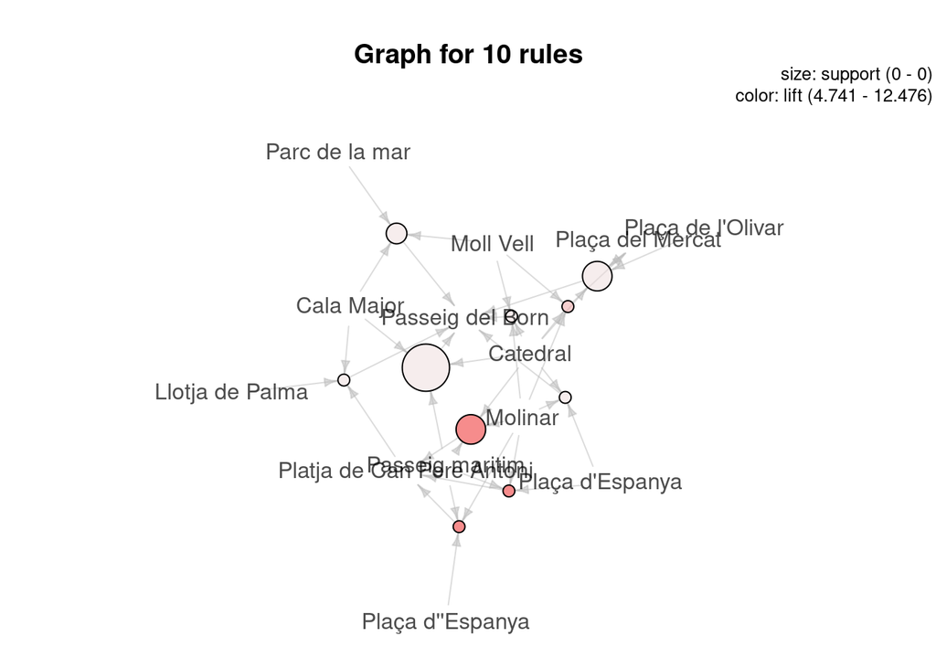

```r
subrules <- head(Items2, n = 10, by = "confidence")
plot(subrules, method = "graph")
```

#Conclusió

En conclusió per poder desenvolupar totes les regles serà necessari totes les dades del dia per realitzar l’estudi. Aquest script solament ha estat una prova per conèixer com s’haguera aplicat a la màquina virtual